# Lab 8

Samantha Kuglen

11/15/2021

```r
knitr::opts_chunk$set(echo = TRUE, warning = FALSE, message = FALSE)

# Attach packages
library(tidyverse)
library(corrplot)
library(stargazer)
library(broom)
library(modelsummary)
library(here)
```

## Read in data

```r
homes <- read_csv(here("data", "slo_homes.csv"))

#unique(homes$City) in console to get unique city names
```

A little bit of cleaning:

Make a subset called homes_sub that only contains observations (rows) where the city is:

- San Luis Obispo
- Arroyo Grande
- Atascadero
- Santa Maria-Orcutt

```r
homes_sub <- homes %>%
  filter(City %in% c("San Luis Obispo", "Arroyo Grande", "Atascadero", "Santa Maria-Orcutt"))
```

## Do a little exploring of our data

Summary statistics (home price, based on city and sale status) - Find & return in a nice summary table the mean and standard deviation of home price, grouped by city and sale status

```r
homes_sub  %>%
  group_by(City, Status) %>%
  summarize(mean_price = round(mean(Price, na.rm = TRUE), 1),
            sd_price = round(sd(Price,na.rm = TRUE), 1))
```

```
## # A tibble: 12 × 4
## # Groups:   City [4]
##    City               Status      mean_price sd_price
##    <chr>              <chr>            <dbl>    <dbl>
##  1 Arroyo Grande      Foreclosure    485120   248832.
##  2 Arroyo Grande      Regular       1013958. 1452501.
##  3 Arroyo Grande      Short Sale     548306.  406906.
##  4 Atascadero         Foreclosure    495864.  284444.
##  5 Atascadero         Regular        477950   266338.
##  6 Atascadero         Short Sale     394422.  210621.
##  7 San Luis Obispo    Foreclosure    339521   119178.
##  8 San Luis Obispo    Regular       1444667.  947813.
##  9 San Luis Obispo    Short Sale     504756.  165482.
## 10 Santa Maria-Orcutt Foreclosure    220392.  140293.
## 11 Santa Maria-Orcutt Regular        321436.  226977.
## 12 Santa Maria-Orcutt Short Sale     233261.   80615.
```

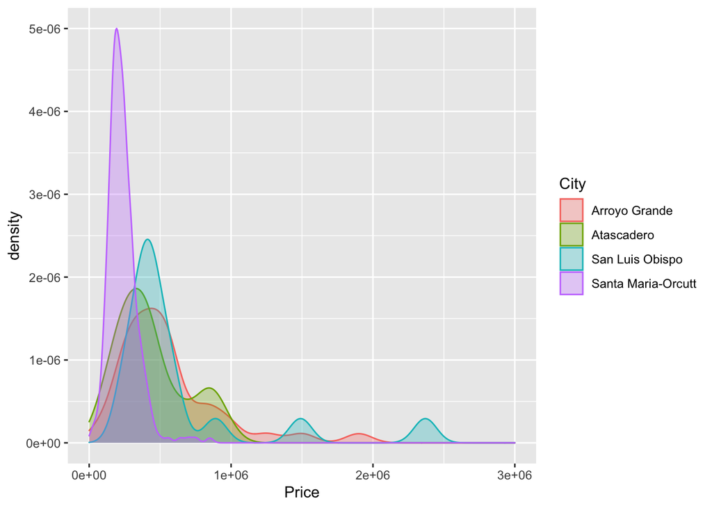

```r
# If you don't want to run this code at all: set eval = FALSE, code not evaluated
# if not referring to a variable, outside of aes
# higher density of homes sold towards lower prices at Santa Maria
ggplot(data = homes_sub, aes(x = Price)) +
  geom_density(aes(color = City, fill = City), alpha = 0.3) +
  scale_x_continuous(limits = c(0, 3e6))
```

Explore the relationship (visual data exploration) between square footage and home price. Change the point COLOR by City and Point shape by sale status

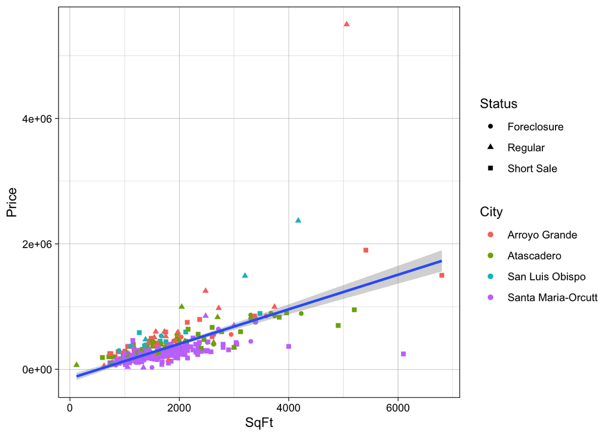

```r
ggplot(homes_sub, aes(x = SqFt, y = Price)) +
  geom_point(aes(color = City, shape = Status)) +
  geom_smooth(method = "lm") +
  theme_linedraw()
```

## Model the relationship with home price as DV

```r
# price per square foot and square foot redundant
# bed and bath correlated... square foot too... correlation about size of the house
homes_lm1 <- lm(Price ~ City + Bedrooms + Bathrooms + SqFt + PricePerSqFt + Status, data = homes_sub)

# Make a subset that only contains the quantitative variables, price, bed, bath, sqft
homes_quant <- homes_sub %>%
  select(Price:PricePerSqFt)

homes_cor <- cor(homes_quant)
homes_cor
```

```
##                  Price    Bedrooms Bathrooms      SqFt PricePerSqFt
## Price        1.0000000  0.27035797 0.4867782 0.6372218   0.75236213
## Bedrooms     0.2703580  1.00000000 0.6429855 0.6195391  -0.04047523
## Bathrooms    0.4867782  0.64298545 1.0000000 0.7721538   0.11223286
## SqFt         0.6372218  0.61953907 0.7721538 1.0000000   0.17961762
## PricePerSqFt 0.7523621 -0.04047523 0.1122329 0.1796176   1.00000000
```

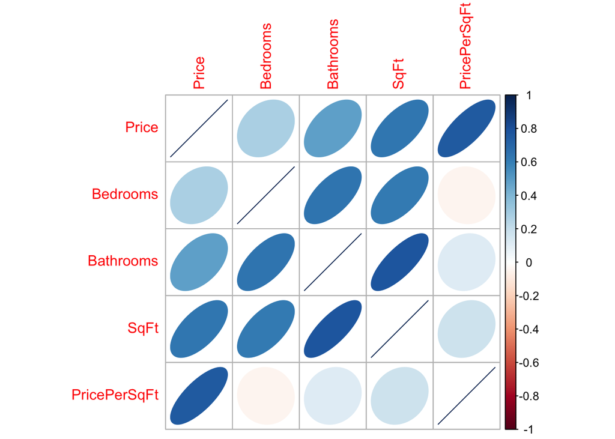

```r
corrplot(homes_cor, method = 'ellipse')
```

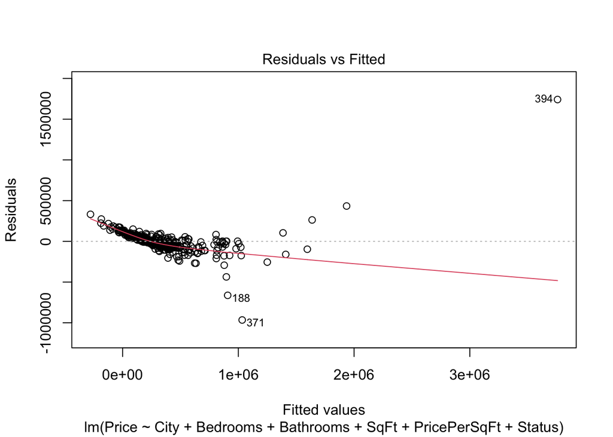

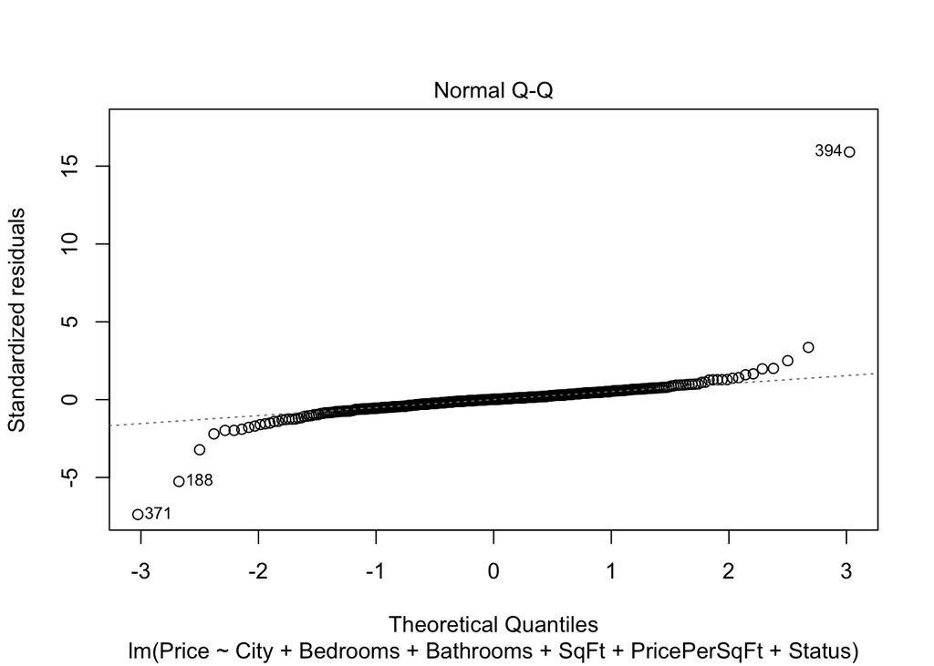

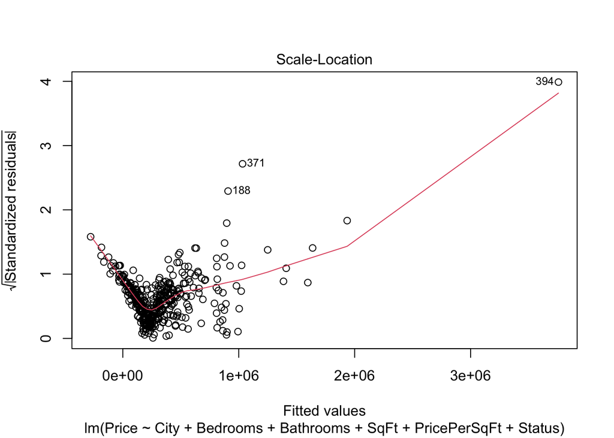

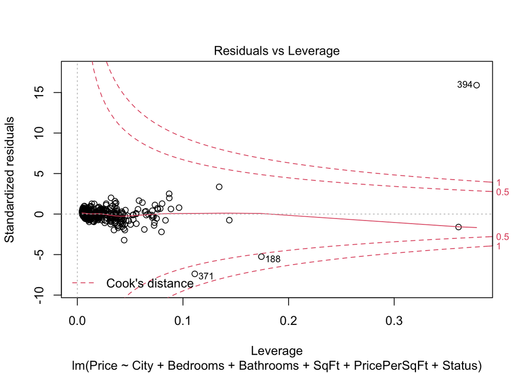

```r
# Interpretting varibales, reference level is City of Arroyo Grande, for
# On average, Atascadero, house costs $9068 less than house in Arroyo Grande
# - $30792, for every additional bedroom, price decreases for each 1 additional bedroom that exists in the house
# Status: reference level is foreclosure, on average, regular sale has lower prices than those in foreclosure
# These don't make sense, redudant in model so reexamine model

# How would I explore diagnostic plots?
plot(homes_lm1)
```

Try another model where we simplify based on concerns: - City - SqFt - Status

```r
homes_lm2 <- lm(Price ~ City + SqFt + Status, data = homes_sub)

homes_lm2
```

```
##
## Call:
## lm(formula = Price ~ City + SqFt + Status, data = homes_sub)
##
## Coefficients:
##            (Intercept)          CityAtascadero     CitySan Luis Obispo
##               106333.1               -202157.5                 34525.4
## CitySanta Maria-Orcutt                    SqFt           StatusRegular
##              -275841.3                   245.9                209998.9
##       StatusShort Sale
##                 2282.4
```

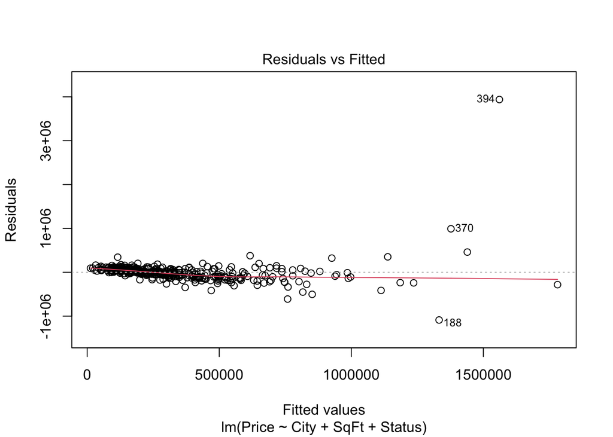

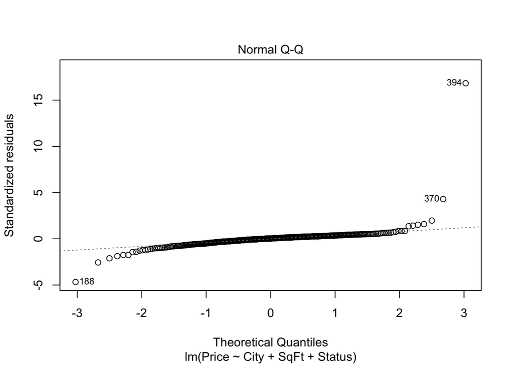

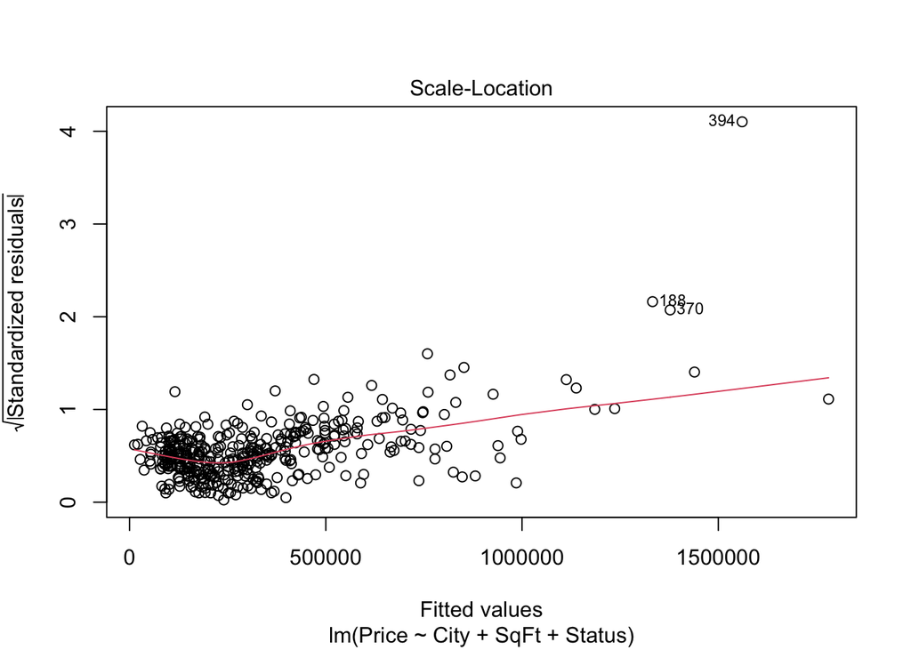

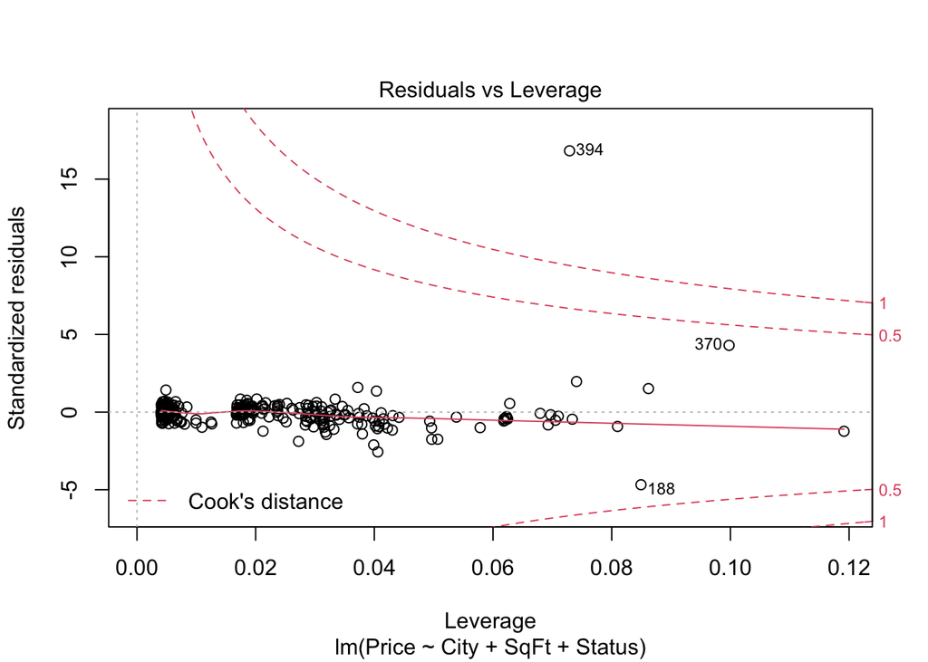

```r
plot(homes_lm2)
```

```r
#use summary(homes_lm2) in the console to view coefficients

# these values more align with what you would expect for home prices, status regular price vs foreclosure price
# R^2 84% of the variance in home price is explained by the predictor variables in this model (city, sqft, status, pricepersqft, bedroom, bathroom)... other variables need to capture 100% of variance in price,
# "adjusted" accounts for increased variables

# ideal model: has high fit and is simple... use AIC
```

Find the AIC value of each model, lower = better balance between model fit and complexity:

```r
AIC(homes_lm1)
```

```
## [1] 10699.25
```

```r
AIC(homes_lm2)
```

```
## [1] 11148
```

Try another permutation of this model that might make sense, check out & compare model fit, outputs, and AIC value

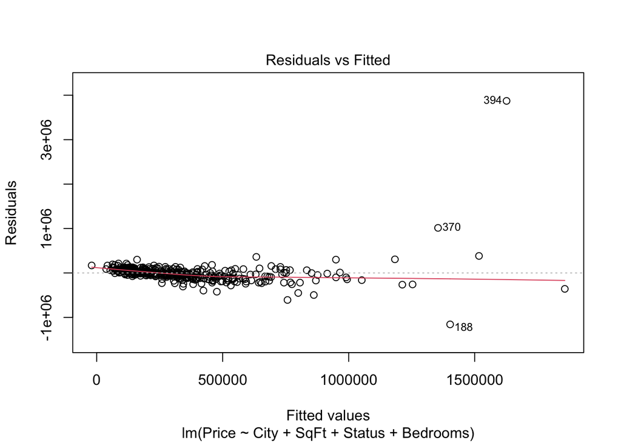

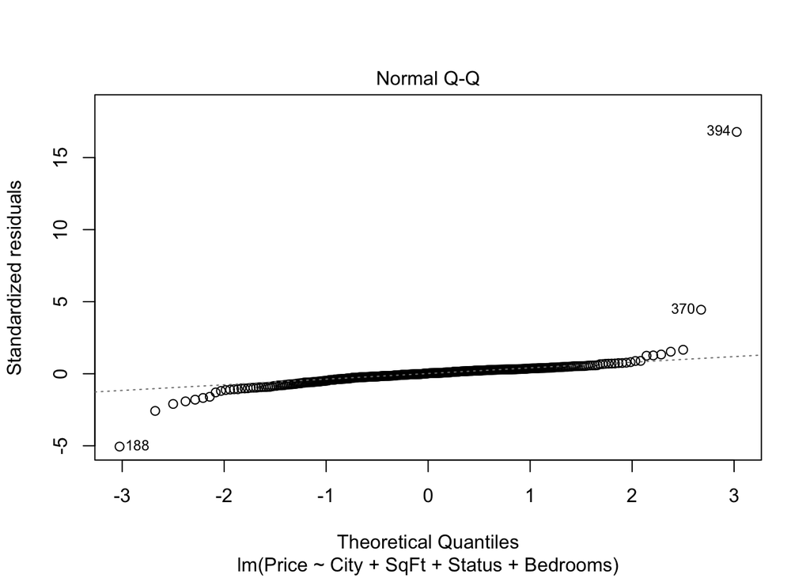

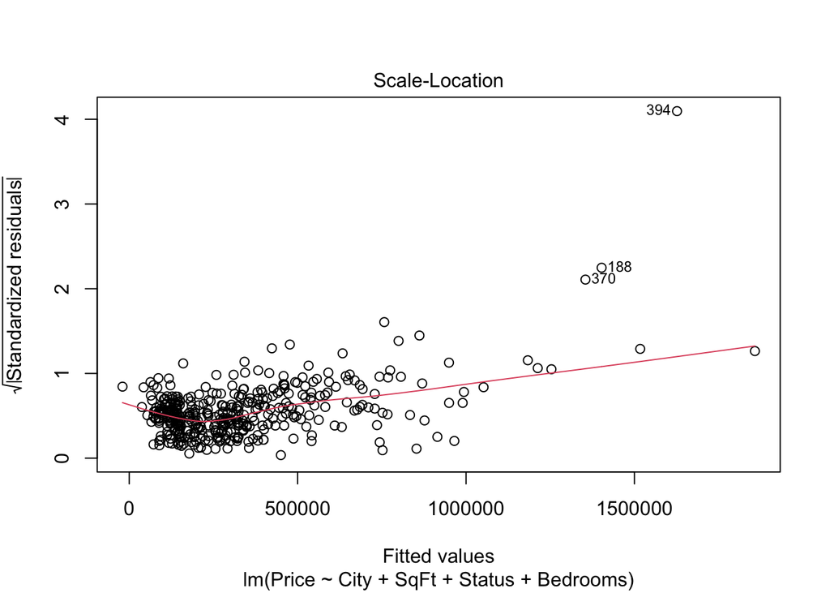

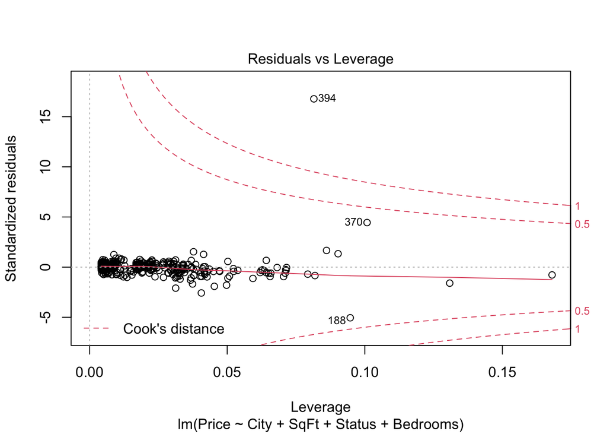

```r
homes_lm3 <- lm(Price ~ City + SqFt + Status + Bedrooms, data = homes_sub)

plot(homes_lm3)
```

```r
summary(homes_lm3)
```

```
##
## Call:
## lm(formula = Price ~ City + SqFt + Status + Bedrooms, data = homes_sub)
##
## Residuals:
##      Min       1Q   Median       3Q      Max
## -1157575   -59536     6015    66999  3872483
##
## Coefficients:
##                          Estimate Std. Error t value Pr(>|t|)
## (Intercept)             195411.31   64547.65   3.027  0.00263 **
## CityAtascadero         -192720.33   48713.65  -3.956 9.03e-05 ***
## CitySan Luis Obispo      30329.41   70175.70   0.432  0.66584
## CitySanta Maria-Orcutt -256745.21   43072.76  -5.961 5.57e-09 ***
## SqFt                       282.59      19.63  14.397  < 2e-16 ***
## StatusRegular           208959.75   49164.06   4.250 2.67e-05 ***
## StatusShort Sale           372.99   32586.28   0.011  0.99087
## Bedrooms                -51934.39   17631.90  -2.945  0.00342 **
## ---
## Signif. codes:  0 '***' 0.001 '**' 0.01 '*' 0.05 '.' 0.1 ' ' 1
##
## Residual standard error: 240800 on 395 degrees of freedom
## Multiple R-squared:  0.5439, Adjusted R-squared:  0.5358
## F-statistic:  67.3 on 7 and 395 DF,  p-value: < 2.2e-16
```

```r
AIC(homes_lm3)
```

```
## [1] 11141.24
```

Use `modelsummary` to show model outputs side-by-side:

If you use modelsummary to return model outputs of multiple models, it wants you to feed it to it as a list.

```r
modelsummary(list(homes_lm1, homes_lm2, homes_lm3))
```

|  | Model 1 | Model 2 | Model 3 |
| --- | --- | --- | --- |
| (Intercept) | −626690.877 | 106333.118 | 195411.312 |
|  | (47272.695) | (57574.568) | (64547.654) |
| CityAtascadero | −9068.194 | −202157.509 | −192720.329 |
|  | (29012.351) | (49077.007) | (48713.650) |
| CitySan Luis Obispo | −76863.041 | 34525.409 | 30329.412 |
|  | (41030.471) | (70837.962) | (70175.703) |
| CitySanta Maria-Orcutt | 120160.701 | −275841.282 | −256745.209 |
|  | (28338.220) | (42992.765) | (43072.762) |
| Bedrooms | −30792.773 |  | −51934.394 |
|  | (10841.581) |  | (17631.905) |
| Bathrooms | 27998.673 |  |  |
|  | (13251.722) |  |  |
| SqFt | 230.726 | 245.934 | 282.586 |
|  | (14.308) | (15.325) | (19.627) |
| PricePerSqFt | 2962.850 |  |  |
|  | (105.537) |  |  |
| StatusRegular | −19792.272 | 209998.857 | 208959.747 |
|  | (29484.606) | (49636.975) | (49164.056) |
| StatusShort Sale | −41575.706 | 2282.420 | 372.987 |
|  | (18900.819) | (32894.066) | (32586.276) |
| Num.Obs. | 403 | 403 | 403 |
| R2 | 0.849 | 0.534 | 0.544 |
| R2 Adj. | 0.846 | 0.527 | 0.536 |
| AIC | 10699.2 | 11148.0 | 11141.2 |
| BIC | 10743.2 | 11180.0 | 11177.2 |
| Log.Lik. | −5338.624 | −5566.000 | −5561.622 |
| F | 245.896 | 75.603 | 67.298 |